# 140.644 - Statistical Machine Learning

Final Project

Martin Skarzynski

March 18, 2018

## Goal

In this project, I was asked to analyse NHANES 2003-2004 data to predict the age and the 9-year survival status for all NHANES participants. ## Background. The National Health and Nutrition Examination Survey (NHANES) is a cross-sectional, nationally representative survey that assesses demographic, dietary and health-related questions and can be used to better understand differences in health and nutrition across the life-span. Almost all survey data are made publically available by the National Center for Health Statistics (NCHS). ## Dataset The dataset for this project includes a pre-compliled set of 813 variables that you can use in your analysis. The dataset includes the following domains:

```
         c(# Demographics
         "DEMO",# Demographic Variables & Sample Weights
         # Dietary
         "DR1TOT", # Dietary Interview - Total Nutrient Intakes, First Day
         "DR2TOT", # Dietary Interview - Total Nutrient Intakes, Second Day
         # Examination
         "BAX", # Balance
         "BPX", # Blood Pressure
         "BMX", # Body Measures
         "CVX", # Cardiovascular Fitness
         "VIX", # Vision
         # Laboratory
         "L13AM",# Cholesterol - LDL & Triglycerides
         "L13", # Cholesterol - Total & HDL
         "L25", # Complete Blood Count with 5-part Differential - Whole Blood
         "L11PSA", # Prostate Specific Antigen (PSA)
         # Questionnaire
         "ALQ", # Alcohol Use
         "BPQ", # Blood Pressure & Cholesterol
         "DIQ", # Diabetes
         "HSQ", # Current Health Status
         "MCQ", # Medical Conditions
         "SSQ", # Social Support
         "WHQ") # Weight History
```

In addition, the dataset includes a 9-year follow-up mortality status obtained from NCHS linked mortality database. Quick introduction to a few variables: - SEQN: Respondent sequence number. - RIDAGEEX: Age in months at time of examination - RIAGENDR: Gender: 1 = male, 2 = female - BMXWT: Weight in kg - BMXHT: Standing Height in cm - BMXBMI: Body mass index (kg/m **2) - mortstat: “final mortality status”; (0 - “Assumed alive”, 1 -“Assumed Deceased”, /* - “Ineligible for mortality follow-up or under age 18”) The full description of the variables is available at the NHANES 2003-2004 website. For example, DEMO and MCQ components are described at DEMO and MCQ, respectively.

# Part 1: A prediction model for the age in months at time of examination, RIDAGEEX

```r
load("nhanes2003-2004.Rda")

#Explore the dataset
dim(nhanes2003_2004)
```

```
## [1] 10122   813
```

```r
#head(nhanes2003_2004)
#names(nhanes2003_2004)
#library(purrr, help)
#map(nhanes2003_2004, class)
library(dplyr, help)
#glimpse(nhanes2003_2004)

#Remove all rows with NAs in the outcome variable column
condition <- !is.na(nhanes2003_2004$RIDAGEEX)
length(condition)
```

```
## [1] 10122
```

```r
nhanes2003_2004 <- nhanes2003_2004[condition,]
#Next, remove all variables with NAs
nhanes2003_2004 <- nhanes2003_2004[,colMeans(is.na(nhanes2003_2004))<=0.00]
# nhanes2003_2004 <- nhanes2003_2004[rowMeans(is.na(nhanes2003_2004))<=0.00,]

#Double check that removeing NAs worked
sum(!is.na(nhanes2003_2004))
```

```
## [1] 226320
```

```r
sum(is.na(nhanes2003_2004))
```

```
## [1] 0
```

```r
dim(nhanes2003_2004)
```

```
## [1] 9430   24
```

```r
#glimpse(nhanes2003_2004)

# Remove factors with fewer than two levels
#str(nhanes2003_2004)
n_lev <- sapply(nhanes2003_2004, nlevels)
#head(n_lev)
nhanes2003_2004 <- nhanes2003_2004[ , n_lev>=2]

which(names(nhanes2003_2004)=="RIDAGEEX")
```

```
## [1] 9
```

```r
#names(nhanes2003_2004)

#Turn all variables to numeric for now
nhanes2003_2004 <- sapply( nhanes2003_2004, as.numeric )
nhanes2003_2004 <- as.data.frame( nhanes2003_2004 )

"RIDAGEEX" %in% names(nhanes2003_2004)
```

```
## [1] TRUE
```

```r
## nhanes2003_2004$RIDAGEEX <- as.numeric(nhanes2003_2004$RIDAGEEX)

set.seed(20180318)

nhanes <-
  nhanes2003_2004 %>%
  rowwise() %>%
  mutate(splt = sample(
    c("train", "test"),
    1,
    replace = TRUE,
    prob = c(0.75, 0.25) # Set weights for each group here
  ))
#head(nhanes)

train <- nhanes %>%
    filter(splt == "train") %>%
    select(-SEQN, -splt)

test <- nhanes %>%
    filter(splt == "test") %>%
    select(-SEQN, -splt)

index_train <- which(nhanes$splt=="train")
index_test <- which(nhanes$splt=="test")
dim(nhanes[index_train,-c(1,24)])
```

```
## [1] 7056   22
```

```r
all(nhanes[index_train,-c(1,24)]==train)
```

```
## [1] TRUE
```

```r
dim(train)
```

```
## [1] 7056   22
```

```r
#names(nhanes)

lin <- lm(formula = RIDAGEEX ~ .,
          data = train,
          na.action = na.omit) #NAs were already removed
```

When $\lambda$ is zero, we should obtain the same results with linear, ridge and lasso regression.

```r
library(glmnet, help)
#convert response variable to vector
y_train <- train$RIDAGEEX
mod_mat <- model.matrix(object = RIDAGEEX ~ ., data = train)
#mod_mat %>% head

rid_cv <- cv.glmnet(mod_mat, y_train, alpha = 0)
rid_lam <- rid_cv$lambda.min
rid_mod <- glmnet(x = mod_mat,
                  y = y_train,
                  alpha = 0,
                  lambda = rid_lam)

las_cv <- cv.glmnet(mod_mat, y_train, alpha = 1)
las_lam <- las_cv$lambda.min
las_mod <- glmnet(x = mod_mat,
                  y = y_train,
                  alpha = 1,
                  lambda = las_lam)

#make predictions
pred_lm <- predict(object = lin, newdata = test)
mean((pred_lm - test$RIDAGEEX)^2)
```

```
## [1] 2779.574
```

```r
test_mat <- model.matrix(RIDAGEEX ~ ., data = test)

rid_pred <- predict(rid_mod, s = rid_lam, newx = test_mat)
mean((rid_pred - test$RIDAGEEX)^2)
```

```
## [1] 3967.504
```

```r
las_pred <- predict(las_mod, s = las_lam, newx = test_mat)
mean((las_pred - test$RIDAGEEX)^2)
```

```
## [1] 2787.77
```

```r
coef(lin)
```

```
##   (Intercept)      BMDSTATS      PEASCST1      RIDSTATR      RIDEXMON
##  3.210740e+01 -2.225614e-01  2.969798e+00            NA  1.221872e+00
##      RIAGENDR      RIDAGEYR      RIDAGEMN      RIDRETH1      RIDRETH2
## -1.097913e-01  1.651047e-01  9.629433e-01 -9.632279e-01  1.166802e+00
##       DMDBORN      DMDCITZN      DMDHHSIZ       SIALANG      SIAPROXY
##  2.319925e-01 -8.185409e+00 -7.772925e-01  7.090095e+00  2.096446e+00
##      SIAINTRP      WTINT2YR      WTMEC2YR       SDMVPSU      SDMVSTRA
## -1.072850e+01  7.094412e-04 -4.627857e-04  1.053173e-01 -1.423998e-01
##      DR1DRSTZ      DR2DRSTZ
## -3.693276e+00  1.648239e+00
```

```r
predict(rid_mod, s = rid_lam, exact = T, type = 'coefficients')
```

```
## 23 x 1 sparse Matrix of class "dgCMatrix"
##                         1
## (Intercept)  80.144337253
## (Intercept)   .
## BMDSTATS      1.186328299
## PEASCST1      3.010562140
## RIDSTATR      .
## RIDEXMON      2.055698820
## RIAGENDR     -0.239904524
## RIDAGEYR      1.359788106
## RIDAGEMN      0.787370334
## RIDRETH1     -1.544006037
## RIDRETH2      0.824958488
## DMDBORN       1.307483464
## DMDCITZN    -13.547197571
## DMDHHSIZ     -4.052524492
## SIALANG      11.954839886
## SIAPROXY      8.938828888
## SIAINTRP    -17.312545231
## WTINT2YR     -0.001575854
## WTMEC2YR     -0.001138606
## SDMVPSU       0.654504185
## SDMVSTRA     -0.192694936
## DR1DRSTZ     -0.800713161
## DR2DRSTZ      0.660650015
```

```r
predict(las_mod, s = las_lam, exact = T, type = 'coefficients')
```

```
## 23 x 1 sparse Matrix of class "dgCMatrix"
##                      1
## (Intercept) 13.5902482
## (Intercept)  .
## BMDSTATS     .
## PEASCST1     .
## RIDSTATR     .
## RIDEXMON     .
## RIAGENDR     .
## RIDAGEYR     0.1332356
## RIDAGEMN     0.9606375
## RIDRETH1     .
## RIDRETH2     .
## DMDBORN      .
## DMDCITZN     .
## DMDHHSIZ     .
## SIALANG      .
## SIAPROXY     .
## SIAINTRP     .
## WTINT2YR     .
## WTMEC2YR     .
## SDMVPSU      .
## SDMVSTRA     .
## DR1DRSTZ     .
## DR2DRSTZ     .
```

The MSEs I obtained are really low, unfortunately, looking at the coefficients it appears that a few of the variables are driving the models. Upon further inspection, `RIDAGEMN` and `RIDAGEYR` is the age in months and years, respectively. I will rerun the models after removing these variables.

```r
train2 <- train %>%
    select(-RIDAGEMN, -RIDAGEYR, -RIDSTATR)

test2 <- test %>%
    select(-RIDAGEMN, -RIDAGEYR, -RIDSTATR)

lin2 <- lm(formula = RIDAGEEX ~ .,
          data = train2,
          na.action = na.omit) #NAs were already removed

#convert response variable to vector
y_train2 <- train2$RIDAGEEX
mod_mat2 <- model.matrix(object = RIDAGEEX ~ ., data = train2)
#mod_mat2 %>% head

rid_cv2 <- cv.glmnet(mod_mat2, y_train2, alpha = 0)
rid_lam2 <- rid_cv2$lambda.min
rid_mod2 <- glmnet(x = mod_mat2,
                  y = y_train2,
                  alpha = 0,
                  lambda = rid_lam2)

las_cv2 <- cv.glmnet(mod_mat2, y_train2, alpha = 1)
las_lam2 <- las_cv2$lambda.min
las_mod2 <- glmnet(x = mod_mat2,
                  y = y_train2,
                  alpha = 1,
                  lambda = las_lam2)

#make predictions
pred_lm2 <- predict(object = lin2, newdata = test2)
mean((pred_lm2 - test2$RIDAGEEX)^2)
```

```
## [1] 67086.84
```

```r
test_mat2 <- model.matrix(RIDAGEEX ~ ., data = test2)

rid_pred2 <- predict(rid_mod2, s = rid_lam2, newx = test_mat2)
mean((rid_pred2 - test2$RIDAGEEX)^2)
```

```
## [1] 67170.32
```

```r
las_pred2 <- predict(las_mod2, s = las_lam2, newx = test_mat2)
mean((las_pred2 - test2$RIDAGEEX)^2)
```

```
## [1] 67092.88
```

```r
coef(lin2)
```

```
##   (Intercept)      BMDSTATS      PEASCST1      RIDEXMON      RIAGENDR
##  644.59400668   14.70610782   16.73483133   13.06993171    6.56668458
##      RIDRETH1      RIDRETH2       DMDBORN      DMDCITZN      DMDHHSIZ
##   -7.92154819  -10.88664541   43.10342921 -120.17079744  -47.43690898
##       SIALANG      SIAPROXY      SIAINTRP      WTINT2YR      WTMEC2YR
##   92.46659665  106.06749533  -96.62026334   -0.01568087   -0.02159239
##       SDMVPSU      SDMVSTRA      DR1DRSTZ      DR2DRSTZ
##    0.16133156   -0.83021491   12.12515026   -9.09910450
```

```r
predict(rid_mod2, s = rid_lam2, exact = T, type = 'coefficients')
```

```
## 20 x 1 sparse Matrix of class "dgCMatrix"
##                         1
## (Intercept)  634.55798922
## (Intercept)    .
## BMDSTATS      14.76046516
## PEASCST1      16.31810247
## RIDEXMON      12.06962470
## RIAGENDR       6.37345939
## RIDRETH1      -7.73782378
## RIDRETH2     -10.43609440
## DMDBORN       38.12304130
## DMDCITZN    -106.13660962
## DMDHHSIZ     -45.76005969
## SIALANG       83.21932075
## SIAPROXY     103.97270981
## SIAINTRP     -92.53809987
## WTINT2YR      -0.01770495
## WTMEC2YR      -0.01981538
## SDMVPSU        0.34838774
## SDMVSTRA      -0.88199384
## DR1DRSTZ      10.87664069
## DR2DRSTZ      -8.27157724
```

```r
predict(las_mod2, s = las_lam2, exact = T, type = 'coefficients')
```

```
## 20 x 1 sparse Matrix of class "dgCMatrix"
##                         1
## (Intercept)  637.63512973
## (Intercept)    .
## BMDSTATS      14.43356411
## PEASCST1      15.97926172
## RIDEXMON      12.29523129
## RIAGENDR       5.91603651
## RIDRETH1      -7.40621496
## RIDRETH2     -10.24691339
## DMDBORN       40.73254601
## DMDCITZN    -114.86491424
## DMDHHSIZ     -47.34453189
## SIALANG       90.00730520
## SIAPROXY     105.84308716
## SIAINTRP     -93.24053506
## WTINT2YR      -0.01565267
## WTMEC2YR      -0.02138917
## SDMVPSU        .
## SDMVSTRA      -0.76740007
## DR1DRSTZ      10.77998070
## DR2DRSTZ      -8.08346165
```

```r
library(randomForest)
rf_mod <- randomForest(RIDAGEEX ~ ., data = train, mtry = ncol(train)-2, ntree = 500)
dim(train)
```

```
## [1] 7056   22
```

```r
rf_pred <- predict(rf_mod, newdata = test)
length(rf_pred)
```

```
## [1] 2374
```

```r
length(test$RIDAGEEX)
```

```
## [1] 2374
```

```r
mean((rf_pred - test$RIDAGEEX)^2)
```

```
## [1] 924.8965
```

```r
rf_mod2 <- randomForest(RIDAGEEX ~ ., data = train2, mtry = ncol(train2)-2, ntree = 500)
dim(train)
```

```
## [1] 7056   22
```

```r
rf_pred2 <- predict(rf_mod2, newdata = test2)
length(rf_pred2)
```

```
## [1] 2374
```

```r
length(test2$RIDAGEEX)
```

```
## [1] 2374
```

```r
mean((rf_pred2 - test2$RIDAGEEX)^2)
```

```
## [1] 50813.24
```

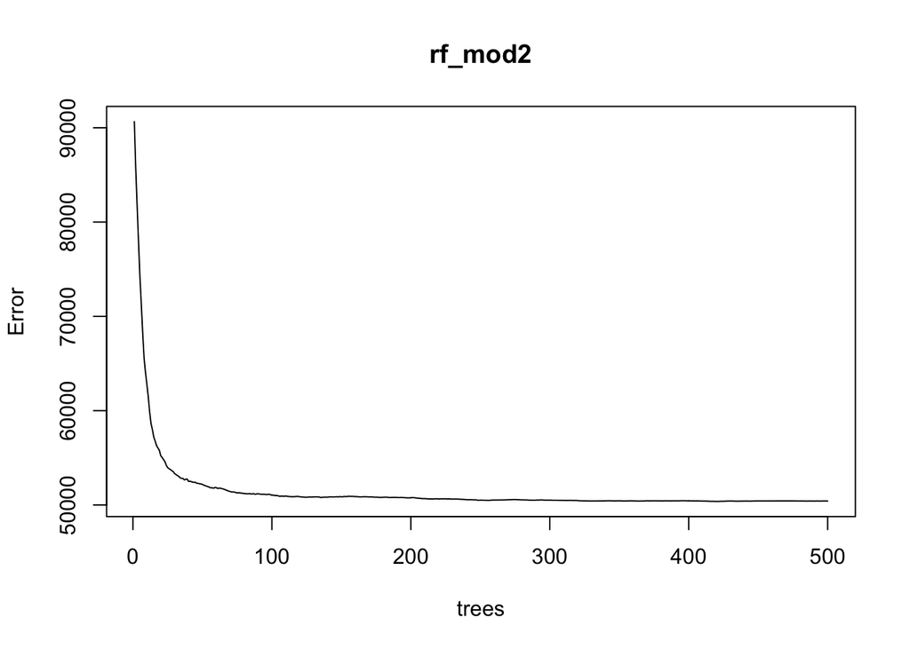

```r
plot(rf_mod2)
```

```r
#boosting
library(gbm)
```

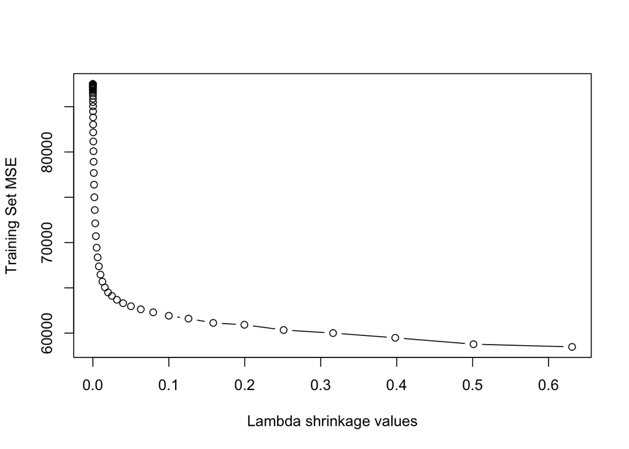

```r
lambdas <- 10^seq(-10, -0.2, by = 0.1)
train_err <- rep(NA, length(lambdas))
for (i in 1:length(lambdas)) {
    boost <- gbm(RIDAGEEX ~ .,
                         data = train2,
                         distribution = "gaussian",
                         n.trees = 500,
                         shrinkage = lambdas[i])
    pred_train <- predict(boost, train2, n.trees = 500)
    train_err[i] <- mean((pred_train - train$RIDAGEEX)^2)
}
plot(lambdas,
     train_err,
     type = "b",
     xlab = "Lambda shrinkage values",
     ylab = "Training Set MSE")
```

Now I will produce a plot with different shrinkage values on the $x$-axis and the corresponding test set MSE on the $y$-axis.

```r
test_err <- rep(NA, length(lambdas))
for (i in 1:length(lambdas)) {
    boost <- gbm(RIDAGEEX ~ .,
                         data = train2,
                         distribution = "gaussian",
                         n.trees = 500,
                         shrinkage = lambdas[i])
    pred_test <- predict(boost, test2, n.trees = 500)
    test_err[i] <- mean((pred_test - test2$RIDAGEEX)^2)
}
plot(lambdas,
     test_err,
     type = "b",
     xlab = "Lambda shrinkage values",
     ylab = "Test Set MSE")
which.min(test_err)
```

```
## [1] 99
```

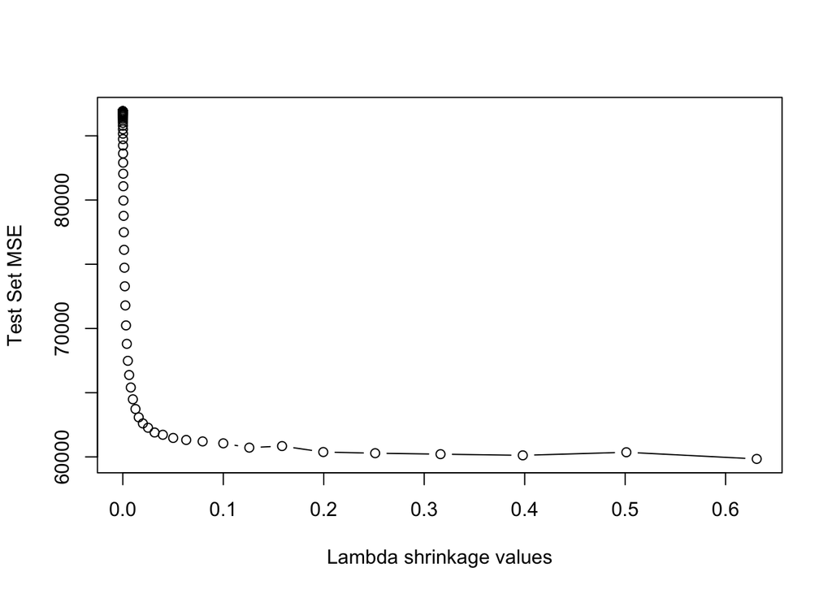

```r
abline(h = which.min(test_err), lty = 2, col = "red")
```

```r
lambdas[which.min(test_err)]
```

```
## [1] 0.6309573
```

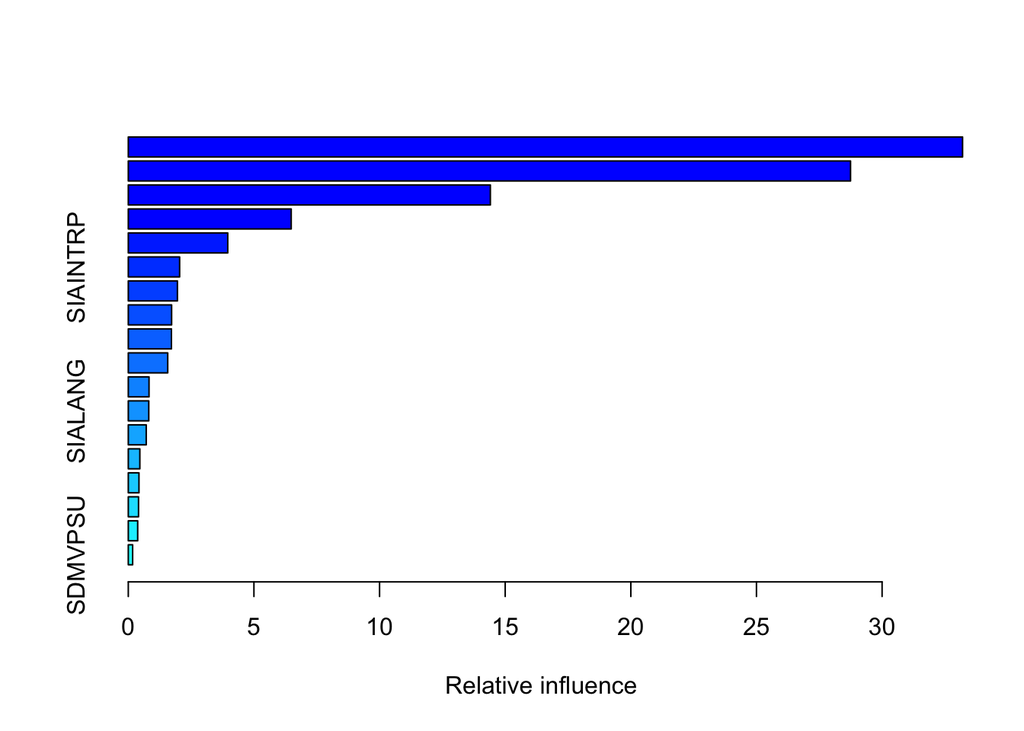

```
##               var    rel.inf
## WTINT2YR WTINT2YR 33.2026711
## WTMEC2YR WTMEC2YR 28.7438620
## DMDHHSIZ DMDHHSIZ 14.4093689
## SDMVSTRA SDMVSTRA  6.4836896
## SIAPROXY SIAPROXY  3.9584048
## SIAINTRP SIAINTRP  2.0429275
## DR1DRSTZ DR1DRSTZ  1.9548301
## PEASCST1 PEASCST1  1.7240094
## RIDRETH1 RIDRETH1  1.7165811
## RIDRETH2 RIDRETH2  1.5696086
## BMDSTATS BMDSTATS  0.8254117
## SIALANG   SIALANG  0.8155386
## RIDEXMON RIDEXMON  0.7138438
## DMDCITZN DMDCITZN  0.4599934
## RIAGENDR RIAGENDR  0.4249995
## DMDBORN   DMDBORN  0.4073661
## DR2DRSTZ DR2DRSTZ  0.3738369
## SDMVPSU   SDMVPSU  0.1730570
```

```r
library(gbm)
boost <- gbm(RIDAGEEX ~ .,
                     data = train2,
                     distribution = "gaussian",
                     n.trees = 1000,
                     shrinkage = lambdas[which.min(test_err)])
summary(boost)
```

From the results above, it appears that WTINT2YR and WTMEC2YR are the most important and second most important variables, respectively, for predicting age using the boosting method.